[figure not shown]

# Solución de Actividades

## Actividad I

### Parte I

Resuelva las siguientes preguntas en `R`:

- Genere un vector con los primeros 1000 números impares.
- Del vector anterior, obtenga los impares número 1, 10, 100 y 1000.
- Cálcule la suma de la raíz de los números generados antes.

#### Solución

```r
impares <- seq(1, by = 2, length.out = 1000)
head(impares)
```

```
## [1]  1  3  5  7  9 11
```

```r
subset <- impares[c(1,10,100,1000)]
subset
```

```
## [1]    1   19  199 1999
```

```r
sum(sqrt(subset))
```

```
## [1] 64.17581
```

### Parte II

Instalamos los siguientes paquetes: `babynames`, `nycflights13`, `maps` y los cargamos junto a `tidyverse`.

```r
# Paquetes #
library(tidyverse)
library(babynames)
library(nycflights13)
library(maps)

# Datasets #
data("births")
data("nycflights13")
data("maps")
```

Considere la tabla `births` paquete `babynames`.

1. ¿Cuántas columnas y filas posee esta tabla?
2. Utilizando un gráfico adecuado, estudie los nacimientos por años en EE.UU. ¿En qué década se obtuvo la menor cantidad de nacimientos?

#### Solución

1. Observemos el `glimpse` de la base de datos:

   ```r
   glimpse(births)
   ```

   ```
   ## Observations: 109
   ## Variables: 2
   ## $ year   <int> 1909, 1910, 1911, 1912, 1913, 1914, 1915, 1916, 1917, 1...
   ## $ births <int> 2718000, 2777000, 2809000, 2840000, 2869000, 2966000, 2...
   ```

   Luego, hay 109 filas y 2 columnas.
2. El siguiente código realiza el gráfico:

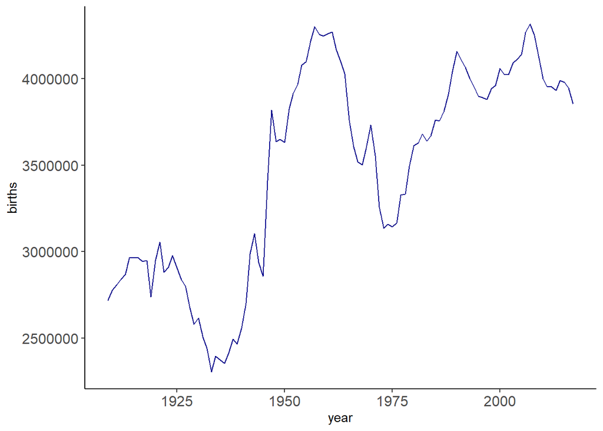

   ```r
   ggplot(data = births) +
     geom_line(aes(x = year, y = births),  col = "darkblue") +
     theme(plot.subtitle = element_text(vjust = 1),
           plot.caption = element_text(vjust = 1),
           axis.line = element_line(linetype = "solid"),
           panel.grid.major = element_line(linetype = "blank"),
           axis.text = element_text(size = 12),
           axis.text.x = element_text(size = 12),
           panel.background = element_rect(fill = NA, linetype = "solid"),
           legend.key = element_rect(fill = "white"),
           legend.background = element_rect(fill = NA, linetype = "solid"))
   ```

   Ahora bien, para obtener la década con menor nacimientos consideramos el siguiente código:

   ```r
   births %>%
     filter(year >= 1910) %>%
     mutate(decade = floor(year/10)*10) %>%
     group_by(decade) %>%
     summarise(nacimientos = sum(births)) %>%
     filter(nacimientos == min(nacimientos))
   ```

   ```
   ## # A tibble: 1 x 2
   ##   decade nacimientos
   ##    <dbl>       <int>
   ## 1   1930    24374000
   ```

   Por lo tanto, la década con menos nacimientos es la década del 30.

### Parte III

Considere ahora la tabla `babynames` del paquete `babynames`.

1. Realice el proceso necesario para obtener la misma estructura en cuanto a **columnas** que la tabla `births`, esto es, generar una nueva tabla que nos entregue el número de nacimientos por año.
2. Genere un data frame partiendo de la tabla `babynames` que contenga los nacimientos de las personas de género femenino con el nombre **Nala, Ariel** y **Elsa** desde los años 1980.
3. Con el data frame obtenido en la parte anterior, genere un gráfico que contenga la información de los nacimientos por año de cada uno de los nombres mencionados y mencionte una hipótesis/suposición al respecto de lo observado. *Hint:* Use `face_wrap(~ name, scales = "free_y")`.

#### Solución

1. El siguiente código realiza lo pedido:

   ```r
   babynames %>%
   group_by(year) %>%
   summarise(births = n() ) -> births2
     head(births2)
   ```

   ```
   ## # A tibble: 6 x 2
   ##    year births
   ##   <dbl>  <int>
   ## 1  1880   2000
   ## 2  1881   1935
   ## 3  1882   2127
   ## 4  1883   2084
   ## 5  1884   2297
   ## 6  1885   2294
   ```

2. El siguiente código realiza lo pedido:

   ```r
   babynames %>%
   filter(sex == "F", year >= 1980, name %in% c("Nala","Ariel","Elsa")) %>%
   arrange(name) -> births3
     head(births3)
   ```

   ```
   ## # A tibble: 6 x 5
   ##    year sex   name      n     prop
   ##   <dbl> <chr> <chr> <int>    <dbl>
   ## 1  1980 F     Ariel   181 0.000102
   ## 2  1981 F     Ariel   228 0.000128
   ## 3  1982 F     Ariel   584 0.000322
   ## 4  1983 F     Ariel   650 0.000363
   ## 5  1984 F     Ariel   636 0.000353
   ## 6  1985 F     Ariel   600 0.000325
   ```

3. El siguiente código resulta en el gráfico pedido

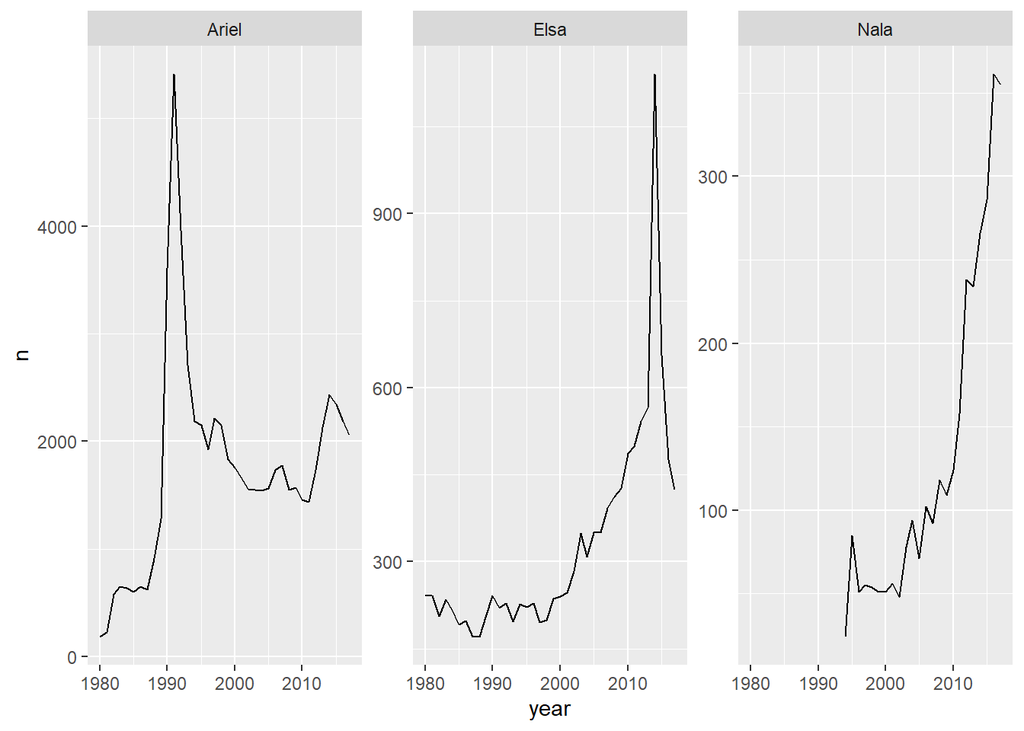

   ```r
   ggplot(data = births3) +
      geom_line(aes(x = year, y = n)) +
      facet_wrap( ~ name, ncol = 3, nrow = 1, scales = "free_y")
   ```

### Parte IV

1. Utilizando las tablas `airports` y `flights` del paquete `nycflights13` obtenga una tabla que contenga conteos de vuelos según su destino `dest` además de la longitud y latitud del aeropuerto(de destino).
2. Apoyándose del siguiente gráfico:

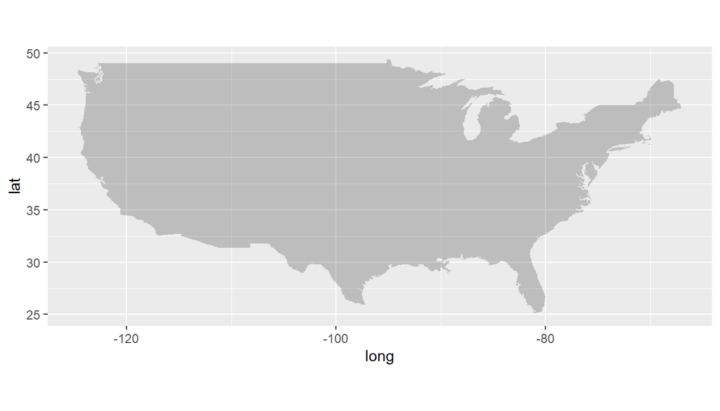

   ```r
   library(maps)
   us <- map_data("state")
   ggmap <- ggplot() +
     geom_polygon(data = us, aes(long, lat, group = group), alpha = 0.25) +
     coord_fixed() # esto es para mantener la razón 1:1
   ggmap
   ```

   1. Agregue una capa de puntos ubicando los aeropuertos obtenidos de la pregunta anterior y usando además: `aes(size = la_cantidad_de_vuelos_a_dicho_aeropuerto)`.
   2. A la izquierda del gráfico anterior se observan 2 puntos. Genere el/los pasos necesarios para seleccionarlos usando la tabla resultante de la pregunta 5 para identificar los nombres de dichos aeropuertos y responda: ¿Donde están? ¿Qué gracias tienen?

#### Solución

1. El siguiente código obtiene lo pedido:

   ```r
   flights %>%
     left_join(airports, by = c("dest" = "faa")) %>%
     group_by(name) %>%
     summarise(nvuelos = n()) %>%
     left_join(airports, by = "name") %>%
     select(name,lat,lon,nvuelos) -> airports2
   head(airports2)
   ```

   ```
   ## # A tibble: 6 x 4
   ##   name                                lat    lon nvuelos
   ##   <chr>                             <dbl>  <dbl>   <int>
   ## 1 Akron Canton Regional Airport      40.9  -81.4     864
   ## 2 Albany Intl                        42.7  -73.8     439
   ## 3 Albuquerque International Sunport  35.0 -107.      254
   ## 4 Asheville Regional Airport         35.4  -82.5     275
   ## 5 Austin Bergstrom Intl              30.2  -97.7    2439
   ## 6 Baltimore Washington Intl          39.2  -76.7    1781
   ```

2. El siguiente código obtiene lo pedido:

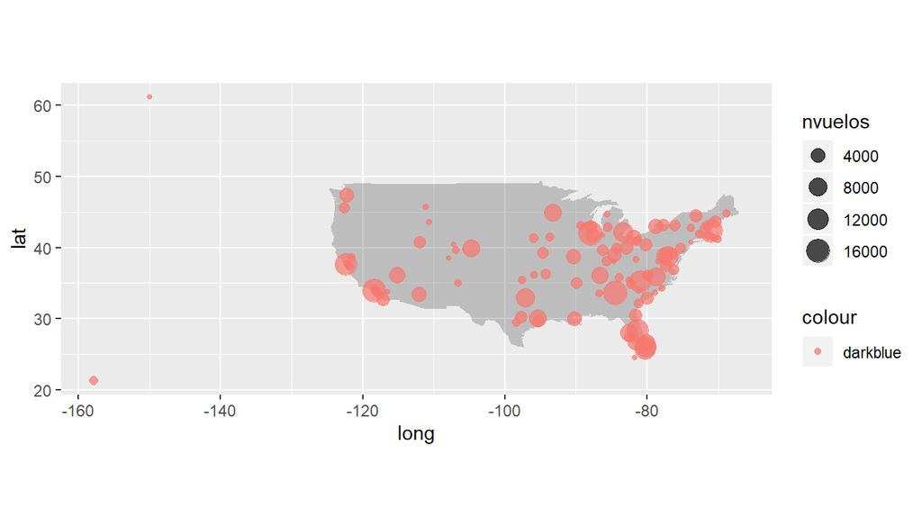

   ```r
   ggmap <- ggplot() +
   geom_polygon(data = us, aes(long, lat, group = group), alpha = 0.25) +
   coord_fixed()
   ggmap + geom_point(data = airports2,
              aes(x = lon, y = lat, size = nvuelos, color = "darkblue"),
              alpha = 0.7)
   ```

   ```r
   airports2 %>%
     filter(lon < -130)
   ```

   ```
   ## # A tibble: 2 x 4
   ##   name                         lat   lon nvuelos
   ##   <chr>                      <dbl> <dbl>   <int>
   ## 1 Honolulu Intl               21.3 -158.     707
   ## 2 Ted Stevens Anchorage Intl  61.2 -150.       8
   ```

## Actividad II

### Parte I

Cree dos funciones para γ(s,x), la primera utilizando la definción y la segunda utilizando su representación en series de potencia. Las funciones no se deben ejecutar si el argumento s es negativo y un mensaje debe ser entregado al usuario.

#### Solución

```r
gam1<- function(s,x){
  if(s < 0) stop("s debe ser positivo")
  myf<-function(t){
    t^(s-1)*exp(-t)
  }
  integrate(myf,0,x)$value
}

gam2<- function(s,x){
  if(s < 0) stop("s debe ser positivo")
  k<-0
  aux<-0
  while (!is.infinite(gamma(s+k+1))){
    aux=sum(x^(0:k)/gamma(s+0:k+1))
    k<-k+1
  }
  ifelse(is.infinite(aux),gamma(s),x^s*gamma(s)*exp(-x)*aux)
}
```

### Parte II

Considere el siguiente conjunto de argumentos :
$$(s,x)\in {(2,5);(2,20);(10,2);(10,20)}.$$
Evalue las funciones creadas anteriormente y la función `Igamma()` del paquete `zipfR`, y compare los resultados. Además, calcule y compare el tiempo de ejecución.

#### Solución

```r
library(zipfR)
library(microbenchmark)
data.frame(Argumentos=c('(2,5)','(2,20)','(10,2)','(10,20)'),
           gam1=c(gam1(2,5),gam1(2,20),gam1(10,2),gam1(10,20)),
           gam2=c(gam2(2,5),gam2(2,20),gam2(10,2),gam2(10,20)),
           Igamma=c(Igamma(2,5),Igamma(2,20),Igamma(10,2),Igamma(10,20)))
```

```
##   Argumentos         gam1         gam2       Igamma
## 1      (2,5) 9.595723e-01 9.595723e-01 9.595723e-01
## 2     (2,20) 1.000000e+00 1.000000e+00 1.000000e+00
## 3     (10,2) 1.687322e+01 1.687322e+01 1.687322e+01
## 4    (10,20) 3.610673e+05 3.610673e+05 3.610673e+05
```

```r
microbenchmark(times = 100, unit = "s", gam1(2,5), gam2(2,5), Igamma(2,3))
```

```
## Unit: seconds
##          expr       min         lq        mean     median         uq
##    gam1(2, 5) 0.0000197 0.00002360 0.000044743 0.00003180 0.00006125
##    gam2(2, 5) 0.0018173 0.00196245 0.002221328 0.00201765 0.00227150
##  Igamma(2, 3) 0.0000031 0.00000430 0.000009217 0.00000650 0.00001305
##        max neval
##  0.0001660   100
##  0.0041231   100
##  0.0000432   100
```

```r
microbenchmark(times = 100, unit = "s", gam1(2,20), gam2(2,20), Igamma(2,20))
```

```
## Unit: seconds
##           expr       min         lq        mean     median         uq
##    gam1(2, 20) 0.0000197 0.00002875 0.000056226 0.00004510 0.00007485
##    gam2(2, 20) 0.0018234 0.00194895 0.002314656 0.00207915 0.00241925
##  Igamma(2, 20) 0.0000033 0.00000495 0.000011625 0.00000930 0.00001530
##        max neval
##  0.0002355   100
##  0.0042766   100
##  0.0000509   100
```

```r
microbenchmark(times = 100, unit = "s", gam1(10,2), gam2(10,2), Igamma(10,2))
```

```
## Unit: seconds
##           expr       min         lq        mean     median         uq
##    gam1(10, 2) 0.0000195 0.00002745 0.000049842 0.00003860 0.00006495
##    gam2(10, 2) 0.0016492 0.00172765 0.001889055 0.00181575 0.00199490
##  Igamma(10, 2) 0.0000031 0.00000445 0.000009466 0.00000700 0.00001385
##        max neval
##  0.0001660   100
##  0.0031378   100
##  0.0000353   100
```

```r
microbenchmark(times = 100, unit = "s", gam1(10,20), gam2(10,20), Igamma(10,20))
```

```
## Unit: seconds
##            expr       min         lq        mean     median         uq
##    gam1(10, 20) 0.0000199 0.00002465 0.000046830 0.00003655 0.00006540
##    gam2(10, 20) 0.0016452 0.00174805 0.001916479 0.00182260 0.00202405
##  Igamma(10, 20) 0.0000031 0.00000440 0.000010010 0.00000735 0.00001555
##        max neval
##  0.0001635   100
##  0.0028149   100
##  0.0000403   100
```

### Parte III

Utilizando las funciones anteriormente implementadas y la función `Igamma()` encuentre el valor de $s$ que minimiza $\gamma(s,x)$ cuando $x=2$, $x=3$, $x=5$ y $x=100$. Compare los resultados y el tiempo de ejecución.

#### Solución

```r
data.frame(x=c(2,3,5,100),
           gam1=c(optimize(gam1,lower=0,upper=4,x=2)$minimum,
                  optimize(gam1,lower=0,upper=4,x=3)$minimum,
                  optimize(gam1,lower=0,upper=4,x=5)$minimum,
                  optimize(gam1,lower=0,upper=4,x=100)$minimum),
           gam2=c(optimize(gam2,lower=0,upper=4,x=2)$minimum,
                  optimize(gam2,lower=0,upper=4,x=3)$minimum,
                  optimize(gam2,lower=0,upper=4,x=5)$minimum,
                  optimize(gam2,lower=0,upper=4,x=100)$minimum),
           Igamma=c(optimize(Igamma,lower=0,upper=4,x=2)$minimum,
                    optimize(Igamma,lower=0,upper=4,x=3)$minimum,
                    optimize(Igamma,lower=0,upper=4,x=5)$minimum,
                    optimize(Igamma,lower=0,upper=4,x=100)$minimum))
```

```
##     x     gam1     gam2   Igamma
## 1   2 2.191667 2.191667 2.191667
## 2   3 1.685979 1.685978 1.685978
## 3   5 1.496323 1.496323 1.496323
## 4 100 1.461634 1.461634 1.461634
```

```r
microbenchmark(times = 100, unit = "s", optimize(gam1,lower=0,upper=4,x=2),
               optimize(gam2,lower=0,upper=4,x=2), optimize(Igamma,lower=0,upper=4,x=2))
```

```
## Unit: seconds
##                                           expr       min         lq
##    optimize(gam1, lower = 0, upper = 4, x = 2) 0.0003506 0.00039825
##    optimize(gam2, lower = 0, upper = 4, x = 2) 0.0254864 0.02598560
##  optimize(Igamma, lower = 0, upper = 4, x = 2) 0.0000468 0.00005410
##         mean     median        uq       max neval
##  0.000450535 0.00043765 0.0004908 0.0009014   100
##  0.027974422 0.02679050 0.0282730 0.0442264   100
##  0.000073571 0.00006920 0.0000821 0.0001574   100
```

```r
microbenchmark(times = 100, unit = "s", optimize(gam1,lower=0,upper=4,x=3),
               optimize(gam2,lower=0,upper=4,x=3), optimize(Igamma,lower=0,upper=4,x=3))
```

```
## Unit: seconds
##                                           expr       min         lq
##    optimize(gam1, lower = 0, upper = 4, x = 3) 0.0006428 0.00069445
##    optimize(gam2, lower = 0, upper = 4, x = 3) 0.0259266 0.02687475
##  optimize(Igamma, lower = 0, upper = 4, x = 3) 0.0000462 0.00004990
##         mean     median         uq       max neval
##  0.000828613 0.00074645 0.00081995 0.0023862   100
##  0.028920582 0.02776345 0.02912550 0.0447161   100
##  0.000074729 0.00006905 0.00008310 0.0001871   100
```

```r
microbenchmark(times = 100, unit = "s", optimize(gam1,lower=0,upper=4,x=5),
               optimize(gam2,lower=0,upper=4,x=5), optimize(Igamma,lower=0,upper=4,x=5))
```

```
## Unit: seconds
##                                           expr       min         lq
##    optimize(gam1, lower = 0, upper = 4, x = 5) 0.0006582 0.00072455
##    optimize(gam2, lower = 0, upper = 4, x = 5) 0.0238407 0.02460315
##  optimize(Igamma, lower = 0, upper = 4, x = 5) 0.0000424 0.00005045
##         mean     median        uq       max neval
##  0.000822814 0.00077865 0.0008481 0.0014839   100
##  0.026429334 0.02532650 0.0267102 0.0421668   100
##  0.000073634 0.00007310 0.0000821 0.0001608   100
```

```r
microbenchmark(times = 100, unit = "s", optimize(gam1,lower=0,upper=4,x=100),
               optimize(gam2,lower=0,upper=4,x=100), optimize(Igamma,lower=0,upper=4,x=100))
```

```
## Unit: seconds
##                                             expr       min        lq
##    optimize(gam1, lower = 0, upper = 4, x = 100) 0.0008191 0.0009059
##    optimize(gam2, lower = 0, upper = 4, x = 100) 0.0291515 0.0316829
##  optimize(Igamma, lower = 0, upper = 4, x = 100) 0.0000482 0.0000553
##         mean     median         uq       max neval
##  0.001304979 0.00100335 0.00134545 0.0174934   100
##  0.037028983 0.03457195 0.04016290 0.0763515   100
##  0.000089153 0.00007650 0.00010760 0.0003016   100
```

## Actividad III

### Parte I

- Si se quiere modelar el tiempo obtenido en la carrera en función de alguna otra variable. ¿Qué variable sugeriría utilizar? Justifique su respuesta indicando las herramientas en las que basó su elección.
- Plantee el modelo adecuado con sus supuestos y ajústelo. Evalúe la significancia de los coeficientes, y en base a ello, escriba la recta estimada.
- Ajuste el modelo de regresión si considerar intercepto. Entregue la recta estimada e interprete el coeficiente en el contexto del problema.

#### Solución

Cargamos los datos:

```r
library(tidyverse)
carrera <- read_delim("http://midas.mat.uc.cl/courses/bc2019/Datasets/carrera.csv", delim = ";")
head(carrera)
```

```
## # A tibble: 6 x 3
##   distancia altura tiempo
##       <dbl>  <dbl>  <dbl>
## 1        25    650  16083
## 2         6   2500   4835
## 3         6    900   3365
## 4        75    800    456
## 5         8   3070  62267
## 6         8   2866  73217
```

Queremos modelar el tiempo utilizando alguna de las otras 2 variables. Para escoger entre una de las dos, miremos su correlación lineal:

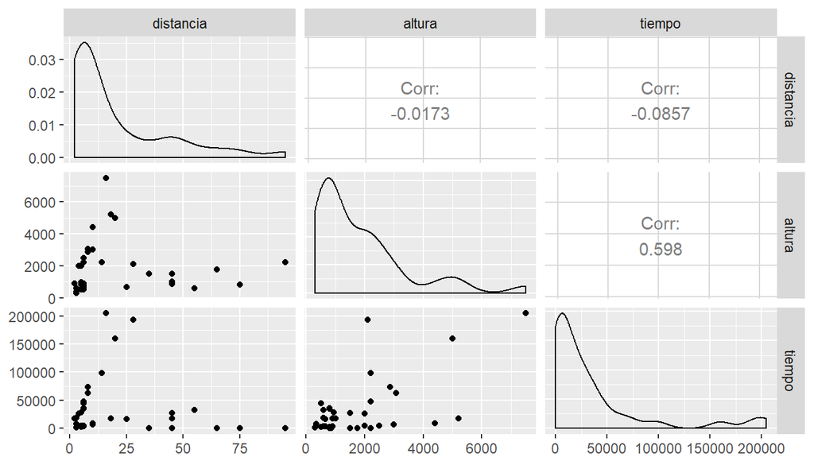

```r
library(GGally)
ggpairs(carrera)
```

En virtud del gráfico de dispersión y del coeficiente de correlación mayor, escogemos la variable altura. El modelo será entonces
$$\text{tiempo}_i = \beta_0 + \beta_1\text{altura}_i + \epsilon_i$$
donde $\epsilon_i \overset{iid}{\sim} \text{N}(0,\sigma^2)$. En `R` tenemos:

```r
modelo1 <- lm(tiempo ~ altura, data = carrera)
summary(modelo1)
```

```
##
## Call:
## lm(formula = tiempo ~ altura, data = carrera)
##
## Residuals:
##    Min     1Q Median     3Q    Max
## -83086 -14903  -1428  14619 152671
##
## Coefficients:
##              Estimate Std. Error t value Pr(>|t|)
## (Intercept)  -727.196  10930.880  -0.067 0.947360
## altura         19.392      4.522   4.288 0.000148 ***
## ---
## Signif. codes:  0 '***' 0.001 '**' 0.01 '*' 0.05 '.' 0.1 ' ' 1
##
## Residual standard error: 42700 on 33 degrees of freedom
## Multiple R-squared:  0.3578, Adjusted R-squared:  0.3384
## F-statistic: 18.39 on 1 and 33 DF,  p-value: 0.0001475
```

Notemos que el coeficiente del intercepto es no significativo, por lo cual deberíamos ajustar un modelo que no lo considerara. De todas maneras, la recta estimada será
$$\hat{\text{tiempo}}_i = -727.2 + 19.39\text{altura}_i.$$
El modelo sin intercepto será:

```r
modelo2 <- lm(tiempo ~ altura - 1,data = carrera)
summary(modelo2)
```

```
##
## Call:
## lm(formula = tiempo ~ altura - 1, data = carrera)
##
## Residuals:
##    Min     1Q Median     3Q    Max
## -82639 -15444  -1816  14323 152418
##
## Coefficients:
##        Estimate Std. Error t value Pr(>|t|)
## altura   19.166      2.942   6.515 1.86e-07 ***
## ---
## Signif. codes:  0 '***' 0.001 '**' 0.01 '*' 0.05 '.' 0.1 ' ' 1
##
## Residual standard error: 42070 on 34 degrees of freedom
## Multiple R-squared:  0.5552, Adjusted R-squared:  0.5421
## F-statistic: 42.44 on 1 and 34 DF,  p-value: 1.862e-07
```

El coeficiente asociado a la altura es significativo. De hecho, el modelo ajustado será
$$\hat{\text{tiempo}}_i = 19.17\text{altura}_i.$$
Gráficamente esto será:

```r
library(ggiraph); library(ggiraphExtra)
ggPredict(modelo2,interactive = TRUE)
```

[interactive chart not shown]

Esto quiere decir que un aumento en una unidad de la altura alcanzada en la carrera significará un aumento de 19.17 minutos en el tiempo de la carrera.

### Parte II

- Grafique los residuos de manera que le permita analizar si está bien especificada la función de la media. Añada las bandas de confianza correspondientes. Identifique qué observaciones son atípicas.
- Obtenga los coeficientes $h_{ii}$ o palanca de cada observación. ¿Qué observación tiene la mayor palanca? Comente este resultado en conjunto con lo obtenido en la pregunta anterior.
- Analice la presencia de observaciones influyentes utilizando las Distancias de Cook y los DFFITS. Comente.

#### Solución

A continuación realizaremos el gráfico de residuos Studentizados versus los valores ajustados del modelo, junto con las respectivas bandas de confianza:

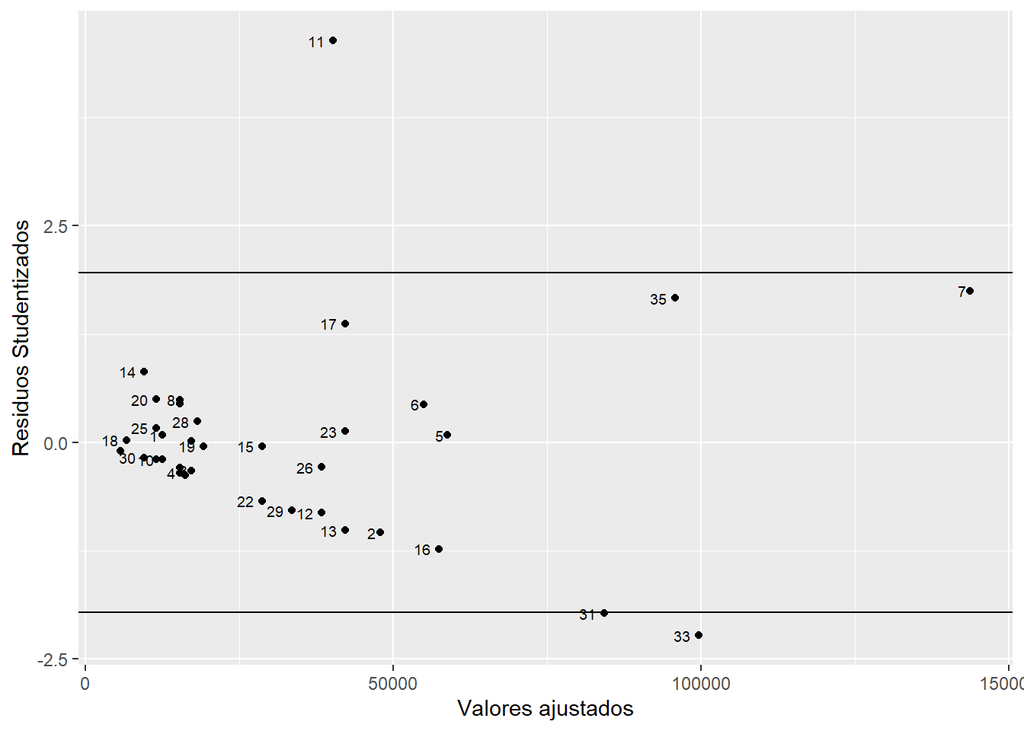

```r
data <- tibble("fit" = modelo2$fitted.values, "res" = rstudent(modelo2), labels = seq(1,nrow(carrera)))
ggplot(data, aes(x = fit, y = res, label = labels)) + geom_point() +
  geom_hline(yintercept = qnorm(0.025)) + geom_hline(yintercept = qnorm(0.975)) +
  geom_text(hjust = 1.5, size = 2.5, check_overlap = TRUE) + xlab("Valores ajustados") +
  ylab("Residuos Studentizados")
```

De aquí vemos que los valores atípicos o outliers son las observaciones 11,31 y 33. Además se observa cierto comportamiento de abertura de megáfono de los datos. Esto nos dice que la función de media no esta bien especificada y que la varianza no cumple el supuesto de homocedasticidad. Para encontrar los $h_{ii}$ junto a las Distancias de Cook y DFFITS utilizamos el siguiente código:

```r
summary(influence.measures(modelo2))
```

```
## Potentially influential observations of
##   lm(formula = tiempo ~ altura - 1, data = carrera) :
##
##    dfb.altr dffit   cov.r   cook.d  hat
## 7   1.08_*   1.08_*  1.30_*  1.10_*  0.28_*
## 11  0.69     0.69_*  0.64_*  0.30    0.02
## 31 -0.64    -0.64_*  1.02    0.37    0.09_*
## 33 -0.87    -0.87_*  1.03    0.68_*  0.13_*
## 35  0.62     0.62_*  1.08    0.37    0.12_*
```

De aquí, los puntos con mayor palanca son el 7,31,33 y 35. Además según Cooks los puntos influyentes son el 7 y el 33, mientras que según DFFIT estos corresponden a 7,11,31,33 y 35. Para analizar el supuesto de independencia basta utilizar el test de Durbin-Watson:

```r
library(lmtest)
dwtest(tiempo ~ altura - 1, data = carrera)
```

```
##
##  Durbin-Watson test
##
## data:  tiempo ~ altura - 1
## DW = 2.0825, p-value = 0.6295
## alternative hypothesis: true autocorrelation is greater than 0
```

Notar que el valor-$p$ es mayor que 0.05, lo que nos dice que no se rechaza la Hipótesis Nula. Por ende, existe evidencia para decir que los errores son independientes. Finalmente, para el supuesto de normalidad observemos el siguiente qqplot:

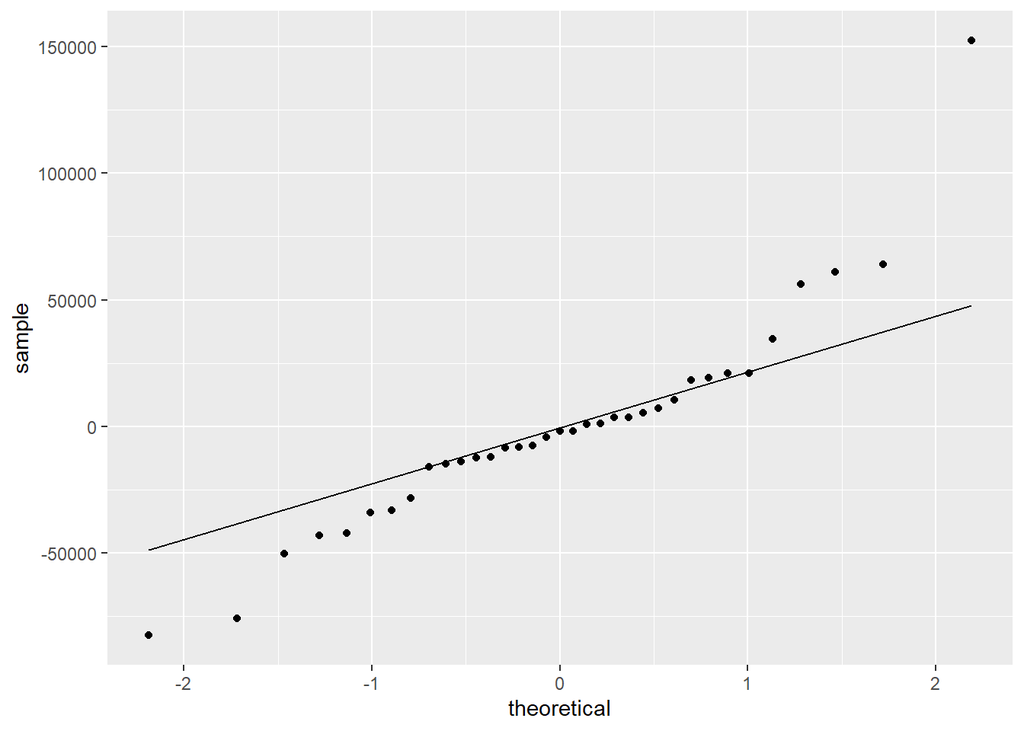

```r
ggplot(tibble("res" = modelo2$residuals), aes(sample = res)) +
  stat_qq() + stat_qq_line()
```

Dado que existen puntos que claramente se escapan de la línea, concluímos que el supuesto de normalidad de los errores no es satisfecho.

## Actividad IV

### Parte I

El archivo `seatbelt.csv` contiene la serie mensual del número de conductores mensualmente muertos o heridos en accidente de tránsito en Gran Bretaña, entre enero de 1969 y diciembre de 1984. Dado lo anterior:

- Importe la BBDD como un `data.frame`.
- Convierta el resultado en una serie de tiempo.
- Estime un modelo de nivel, pendiente y estacionalidad local.
- Grafique los componentes tendencial y estacional ya suavizados.

#### Solución

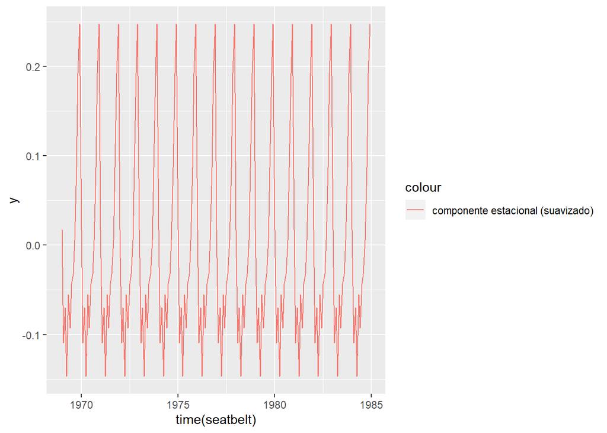

```r
# Declara las librerías relevantes
library(tidyverse)
library(magrittr)
library(readr)
library(KFAS)

# Importa la BBDD
seatbelt <- readr::read_csv("../Datasets/seatbelt.csv")

# Convierte el resultado en una serie de tiempo
seatbelt <- ts(seatbelt, frequency = 12, start = c(1969, 1))

# Ajusta un modelo estructural (a la Harvey) a estos datos
Q_trend <- list(matrix(NA), matrix(NA))
Q_seas  <- matrix(NA)
fit_01 <-
  KFAS::SSModel(
    seatbelt ~ -1 + SSMtrend(2, Q_trend) + SSMseasonal(12, Q_seas),
    H = matrix(NA),
    data = seatbelt
  ) %>%
  KFAS::fitSSM(inits = rep(0, 4))

# Aplica el KFS al resultado
kfs_01 <-
  fit_01 %>%
  magrittr::extract2("model") %>%
  KFAS::KFS() %>%
  magrittr::extract2("alphahat")

# Grafica el componente estacional suavizado
smo <- kfs_01[, 3]
ggplot(tibble(y = smo), aes(x = time(seatbelt))) +
  geom_line(aes(y = y,   colour = "componente estacional (suavizado)"))
```

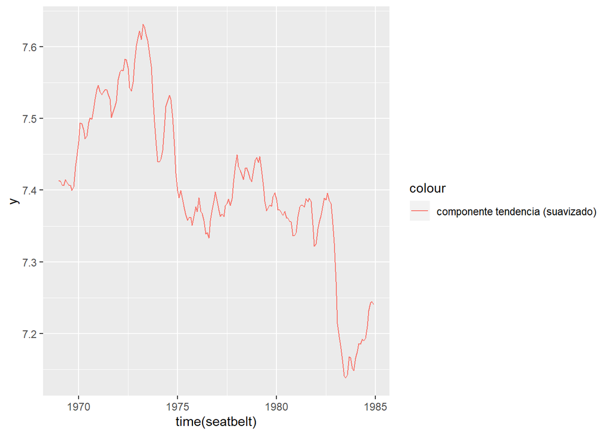

```r
# Grafica el componente tendencial suavizado
smo <- kfs_01[, 1]
ggplot(tibble(y = smo), aes(x = time(seatbelt))) +
  geom_line(aes(y = y,   colour = "componente tendencia (suavizado)"))
```

### Parte II

- Reconsidere el ejemplo dado para el filtro de Hamilton.
- Estime un modelo de nivel, pendiente y estacionalidad local y grafique la tendencia suavizada. ¿Cómo luce en relación a lo obtenido con el filtro de Hamilton?
- Repita el ejercicio anterior, pero ahora con una pendiente no local sino global.

#### Solución

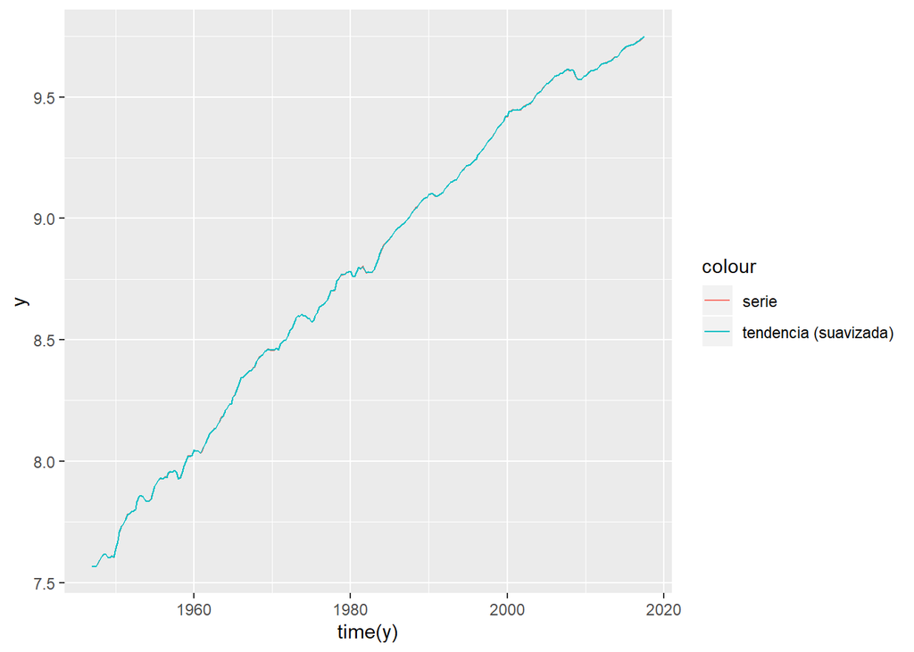

```r
# Declara las librerías relevantes
library(neverhpfilter)
library(tidyverse)
library(magrittr)
library(KFAS)

# Prepara los datos
y <- ts(log(neverhpfilter::GDPC1), frequency = 4, start = c(1947, 1))

# Calcula la tendencia suavizada (usando un modelo estructural a la Harvey)
smo_trend_01 <-
  KFAS::SSModel(
    y ~ -1 + SSMtrend(2, Q_trend) + SSMseasonal(4, Q_seas),
    H = matrix(NA),
    data = y
  ) %>%
  KFAS::fitSSM(inits = rep(0, 4)) %>%
  magrittr::extract2("model") %>%
  KFAS::KFS() %>%
  magrittr::extract2("alphahat") %>%
  magrittr::extract(, 1)

# Grafica el resultado (junto a la serie original)
ggplot(NULL, aes(x = time(y))) +
  geom_line(aes(y = y,            colour = "serie")) +
  geom_line(aes(y = smo_trend_01, colour = "tendencia (suavizada)"))
```

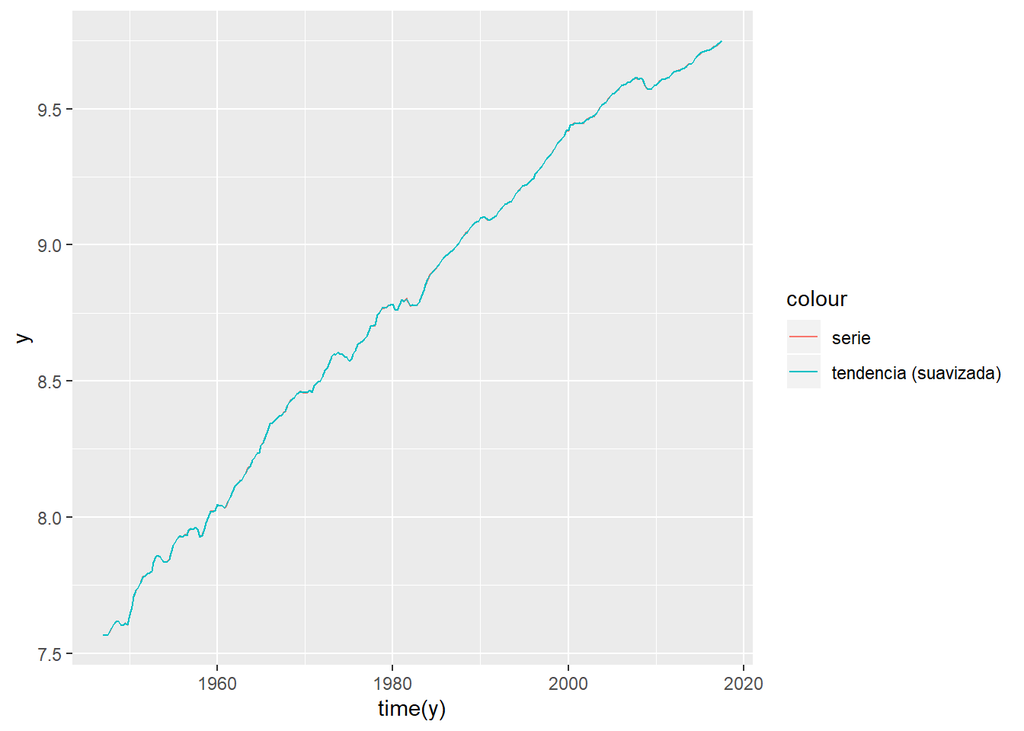

```r
# Calcula la tendencia suavizada (pero ahora usado estacionalidad global)
Q_trend <- list(matrix(NA), 0)
Q_seas  <- matrix(NA)
smo_trend_02 <-
  KFAS::SSModel(
    y ~ -1 + SSMtrend(2, Q_trend) + SSMseasonal(4, Q_seas),
    H = matrix(NA),
    data = y
  ) %>%
  KFAS::fitSSM(inits = rep(0, 3)) %>%
  magrittr::extract2("model") %>%
  KFAS::KFS() %>%
  magrittr::extract2("alphahat") %>%
  magrittr::extract(, 1)

# Grafica el resultado (junto a la serie original)
ggplot(NULL, aes(x = time(y))) +
  geom_line(aes(y = y,            colour = "serie")) +
  geom_line(aes(y = smo_trend_02, colour = "tendencia (suavizada)"))
```

### Parte III

Los archivos `ENE 2018 07 JJA.dta` y `ENE 2019 07 JJA.dta` contienen submuestras de la Encuesta Nacional de Empleo para los trimestres junio-agosto de 2018 y 2019, respectivamente.

1. Importe ambas BBDD a R.
2. Estime el número de ocupados, según trimestre.
3. Estime la variación porcentual en 12 meses del n. de ocupados.
4. Estime el número de ocupados por grupo ocupacional, según trimestre.
5. Estime la variación (%) en 12 meses del n. de ocupados por grupo de ocupación.
6. Estime la distribución de los ocupados por grupo de ocupación, según trimestre.
7. Presente los resultados del ítem anterior en un solo cuadro.
8. Presente los resultados del ítem anterior en un solo gráfico.

#### Solución

1. Carga los datos (también cargaremos datos del 2018):

   ```r
   ene_jja <- list(
     "2018" = haven::read_dta("../Datasets/ENE 2018 07 JJA.dta"),
     "2019" = haven::read_dta("../Datasets/ENE 2019 07 JJA.dta")
   )
   ```

2. Estima el número de ocupados, para los trimestres junio-agosto 2018 y 2019

   ```r
   ocup_2018 <-
     ene_jja[["2018"]] %>%
     dplyr::filter(activ == 1) %>%
     dplyr::summarise(n = sum(fact)) %>%
     dplyr::pull(1)

   ocup_2019 <-
     ene_jja[["2019"]] %>%
     dplyr::filter(activ == 1) %>%
     dplyr::summarise(n = sum(fact)) %>%
     dplyr::pull(1)
   ```

3. Estima la variación porcentual en 12 meses del número de ocupados

   ```r
   ocup_vp <- round(100 * (ocup_2019 - ocup_2018) / ocup_2019, 1)
   ```

4. Estima el número de ocupados, según grupo ocupacional (CIUO 08.cl) para los trimestres junio-agosto 2018 y 2019

   ```r
   tbl1_2018 <-
     ene_jja[["2018"]] %>%
     dplyr::select(activ, b1, fact) %>%
     dplyr::filter(activ == 1) %>%
     dplyr::group_by(b1) %>%
     dplyr::summarise(n = sum(fact))

   tbl1_2019 <-
     ene_jja[["2019"]] %>%
     dplyr::select(activ, b1, fact) %>%
     dplyr::filter(activ == 1) %>%
     dplyr::group_by(b1) %>%
     dplyr::summarise(n = sum(fact))
   ```

5. Estima el cambio porcentual del número de ocupados, según grupo ocupacional (CIUO 08.cl) entre los trimestres JJA 2018 y JJA 2019

   ```r
   tbl1 <-
     dplyr::inner_join(tbl1_2018, tbl1_2019, by = "b1") %>%
     dplyr::mutate(delta = 100 * (n.y - n.x) / n.x) %>%
     dplyr::arrange(desc(delta)) %>%
     haven::as_factor()
   ```

Convierte el resultado en un vector

[output not shown]

6. Estima la participación de ocupados (en %), según grupo ocupacional (CIUO 08.cl) para los trimestres junio-agosto 2018 y 2019

   ```r
   tbl2_2019 <-
     ene_jja[["2019"]] %>%
     dplyr::select(activ, b1, fact) %>%
     dplyr::filter(activ == 1) %>%
     dplyr::group_by(b1) %>%
     dplyr::summarise(n = sum(fact)) %>%
     dplyr::mutate(
   pct       = 100 * n / sum(n),
   trimestre = "junio-agosto 2019"
     )

   tbl2_2018 <-
     ene_jja[["2018"]] %>%
     dplyr::select(activ, b1, fact) %>%
     dplyr::filter(activ == 1) %>%
     dplyr::group_by(b1) %>%
     dplyr::summarise(n = sum(fact)) %>%
     dplyr::mutate(
   pct       = 100 * n / sum(n),
   trimestre = "junio-agosto 2018"
     )
   ```

7. Combina la información en una tabla

   ```r
   tbl2_3FN <-
     rbind(tbl2_2018, tbl2_2019) %>%
     dplyr::select(b1, pct, trimestre) %>%
     dplyr::mutate(
   trimestre = haven::as_factor(trimestre),
   b1        = haven::as_factor(b1)
     )
   ```

8. Combina la información en un gráfico

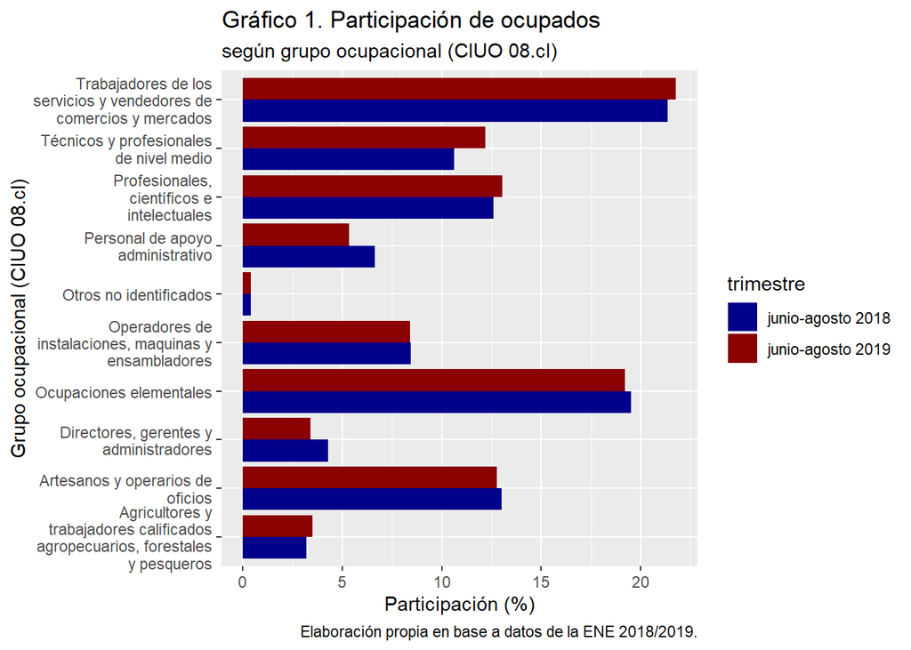

   ```r
   tbl2_3FN %>%
     ggplot2::ggplot(aes(stringr::str_wrap(b1, 25), pct, fill = trimestre)) +
     ggplot2::geom_bar(position = "dodge", stat = "identity") +
     ggplot2::coord_flip() +
     ggplot2::scale_fill_manual(values = c("darkblue", "darkred")) +
     ggplot2::labs(
   x        = "Grupo ocupacional (CIUO 08.cl)",
   y        = "Participación (%)",
   title    = "Gráfico 1. Participación de ocupados",
   subtitle = "según grupo ocupacional (CIUO 08.cl)",
   caption  = "Elaboración propia en base a datos de la ENE 2018/2019."
     )
   ```